# act_report

## Act Report

### Dataset: WeRateDogs Twitter Data

### About Dataset:

WeRateDogs is a Twitter account that rates people's dogs with a humorous comment about the dog. These ratings almost always have a denominator of 10. The numerators, though? Almost always greater than 10. 11/10, 12/10, 13/10, etc. Why? Because "they're good dogs Brent." WeRateDogs has over 4 million followers and has received international media coverage.

### Insights:

Here are the insights generated from this dataset

1. Retweets and Likes Metrics on the WeRateDogs Platform

The WeRateDogs platform has generated retweet counts with the highest being 79,515 and the lowest being 16. While also generating likes from as high as 132,810 to as low as 81, making it quite a popular platform.

1. Breeds Diversity and Most Common Breeds on the WeRateDogs Platform

There are 373 different breeds of dogs that have appeared on the WeRateDogs platform, with the top 5 most common breeds being Golden Retrievers, Labrador Retrievers, Pembrokes, Chihuahuas and Pugs.

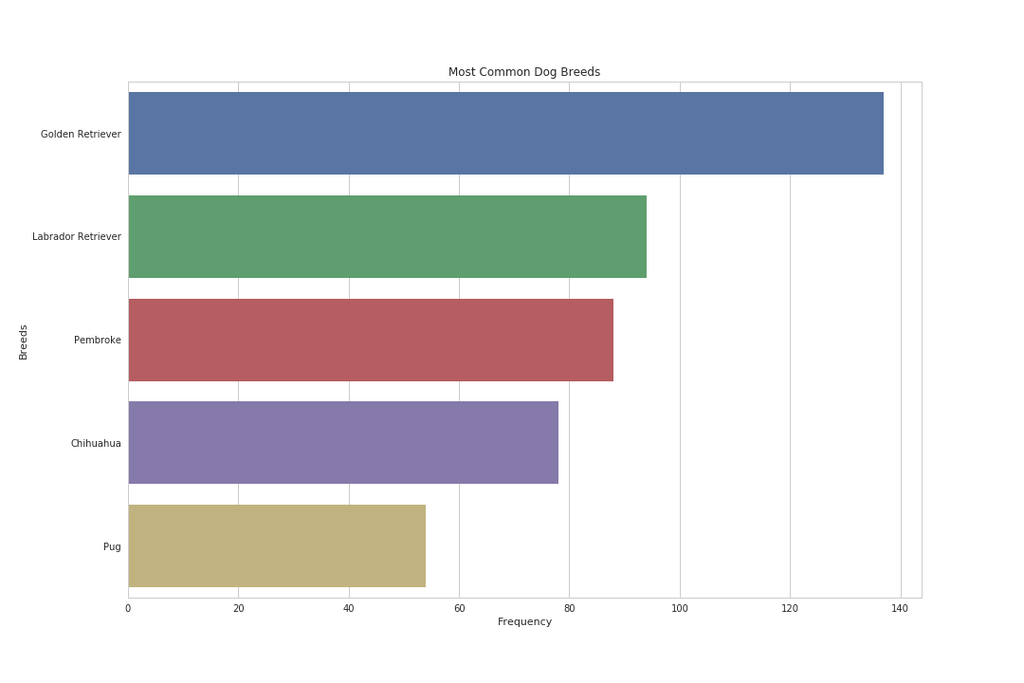

1. Most Common Dog Stages on the WeRateDogs Platform

The number of unique Dog Stages is- 7 The most common dog stage is the Pupper stage meaning most dogs appearing on the WeRateDogs platform are puppies.

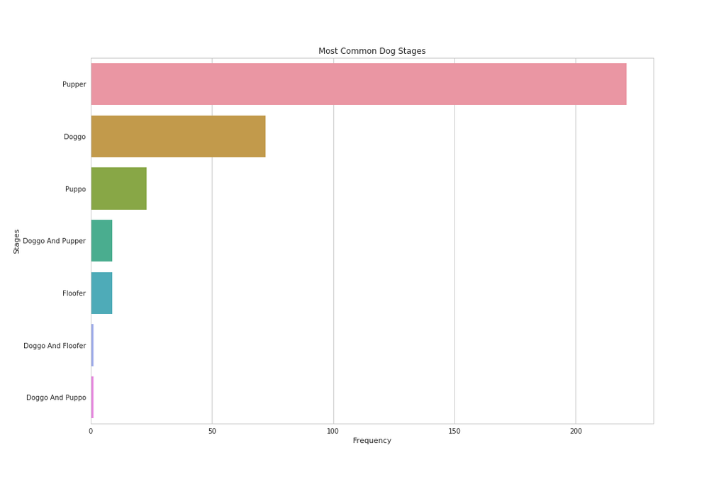

1. WeRateDogs Rating System

The highest rating on the platform according to the WeRateDogs rating system 1776/10, although not much can be made of this as there's clear evidence of humorous ratings that the platform is noted for (They are good dogs Brent), and outliers. The most common rating on the platform is 12/10. Closely followed by 10/10 and 11/10. The ratings clearly show that WeRateDogs really love their dogs, afterall, They're good dogs Brent.

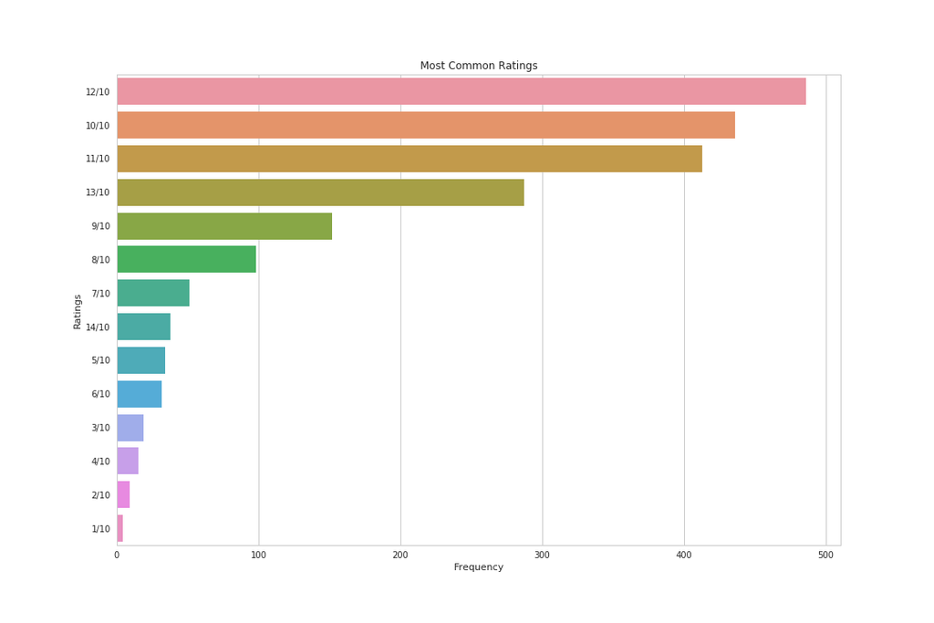